# Kevin’s 3 Pointers

Kevin Peng

## Introduction

Similar to my first project, I decided to analyze my own basketball game. Instead of playing a 1v1 game versus someone, I decided to record shots from around the 3-point line and determine shooting patterns. The three hypothesis that I explore are:

1.) For any given, unguarded, practice shot, I have >= 50% chance of making it.

2.) After making a shot, the next shot will have a higher chance of going in.

3.) I am more likely to go on a make streak from the left side of the court compared to the right side.

## Methods

In order to collect this data, I asked a friend to sit on the side and record me taking 100 shots, 20 from 5 different points around the three point line: The corners, the wings, and the top of the key, looking towards the baseline (Figure 1). With each shot, there were variables considered, which are in the data dictionary below.

The inferencial models used for linear regression were:

1.) shots_made compared to the shot_number

2.) shot_made_streak compared to the shot_number

The model used for inference of the mean:

1.) shot_made_streak compared to location of the shot.

#### Data dictionary for the dataset “three_data”:

- location: location on the court where a shot was taken. Options can be seen around the three point line of Figure 1.
- shot_number: a numeric variable 1-100 describing which shot is being taken.
- shots_made: a numeric variable counter that describes how many shots were made
- shot_made_streak: a numeric variable that acts as a counter keeping track of consecutive shots made.
- made_miss_streak: a categorical variable describing the streak type that is happening at a given shot_number. Options include: miss_X, and make_X, where X is an positive integer of the streak.

[Figure 1. Shot locations](https://www.coachesclipboard.net/images/xHalfCourtTerms.gif.pagespeed.ic.f_tQMgajQe.png)

## Results

### Linear Regression

```
##
## Call:
## lm_basic(formula = shots_made ~ 1 + shot_number, data = three_data)
##
## Residuals:
##      Min       1Q   Median       3Q      Max
## -1.78292 -0.47012  0.00146  0.49085  1.90438
##
## Coefficients:
##             Estimate   2.5 % 97.5 %
## (Intercept)  -0.2976 -0.5900 -0.005
## shot_number   0.5166  0.5116  0.522
##
## Residual standard error: 0.7314 on 98 degrees of freedom
## Multiple R-squared:  0.9976, Adjusted R-squared:  0.9976
## F-statistic: 4.157e+04 on 1 and 98 DF,  p-value: < 2.2e-16
```

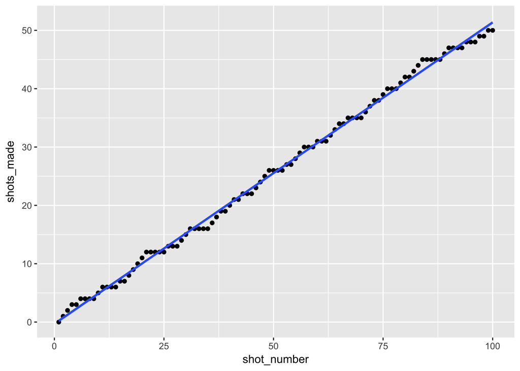

This plot shows a line y = ax + b, where y is the number of shots made, x is the number of shots taken and a/b are the intercept and slope from the linear regression. The formula and plot both show a positive relationship between the variables, which is expected, and a line that predicts, if I take x-amount of shots, I will make y of them.

```
##
## Call:
## lm_basic(formula = shot_made_streak ~ 1 + shot_number, data = three_data)
##
## Residuals:
##     Min      1Q  Median      3Q     Max
## -1.2075 -0.9026 -0.4171  0.8099  3.9086
##
## Coefficients:
##              Estimate     2.5 % 97.5 %
## (Intercept)  1.213333  0.751790  1.675
## shot_number -0.005809 -0.013743  0.002
##
## Residual standard error: 1.154 on 98 degrees of freedom
## Multiple R-squared:  0.02108,    Adjusted R-squared:  0.01109
## F-statistic:  2.11 on 1 and 98 DF,  p-value: 0.1495
```

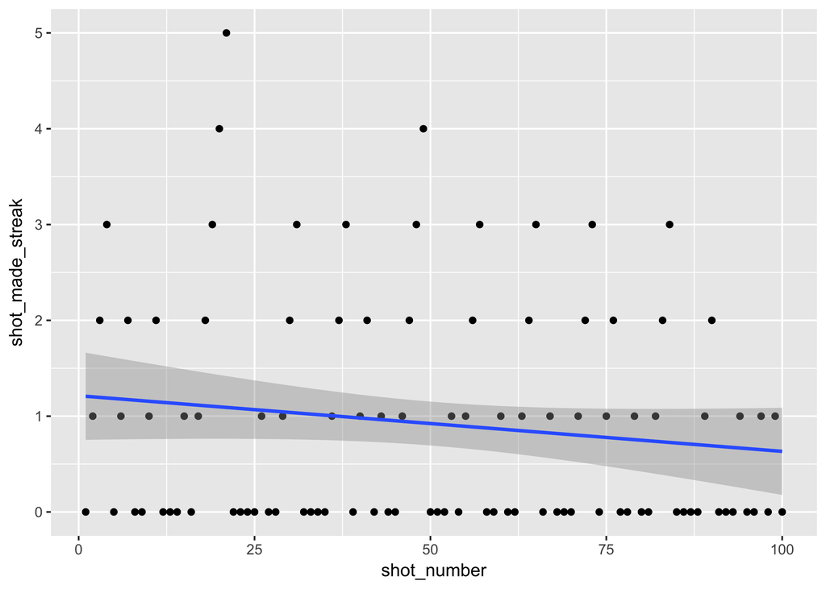

### Inference for the mean

```
##
## Call:
## lm_basic(formula = shot_made_streak ~ 1 + location, data = three_data)
##
## Residuals:
##    Min     1Q Median     3Q    Max
## -1.150 -0.950 -0.375  0.850  4.050
##
## Coefficients:
##                      Estimate   2.5 % 97.5 %
## (Intercept)            1.1500  0.6311  1.669
## locationleft_wing     -0.2000 -0.9338  0.534
## locationright_corner  -0.5500 -1.2838  0.184
## locationright_wing    -0.3000 -1.0338  0.434
## locationtop_key       -0.1000 -0.8338  0.634
##
## Residual standard error: 1.169 on 95 degrees of freedom
## Multiple R-squared:  0.02669,    Adjusted R-squared:  -0.01429
## F-statistic: 0.6514 on 4 and 95 DF,  p-value: 0.6273
```

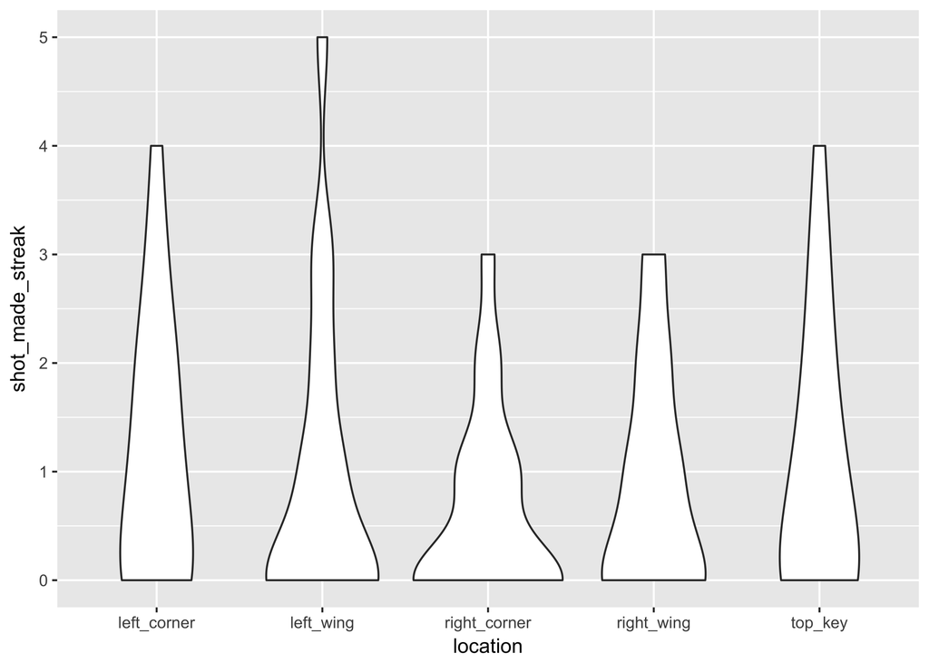

The violin plot shows the relationship between locations and average shot streak. The regression table shows how each location affects the average shot streak, each named based off Figure 1.

## Conclusions

#### Linear regression test

The relationship between shots_made and shot_number show a positive relationship, and more importantly, above 0.50 for the slope when considering shots_made. When I plug in a number 100, for the shot_number, the linear regression predicts a number of shots made as ~51.3 made. Combined with the multiple R-squared statistic being close to 1 and the intercepts and slope not including 0, I am confident with the result and that there is at least a 50% chance that I make a wide open 3-point shot, and can confirm the first hypothesis.

The slope on the other hand, was between -0.013743 and 0.002. Despite the upper bound being barely above 0, I would not consider the shot number as being statistically significant, as in addition, the multiple R-squared statistic is close to 0. As a result, we can also conclude that shot number does not affect the probability of making consecutive buckets.

Despite rejecting the second hypothesis, the plot for it showed an interesting trend. As I shot more, I was going on less streaks. I believe this may have to do with fatigue as I shot more shots.

## References

1. https://www.coachesclipboard.net/images/xHalfCourtTerms.gif.pagespeed.ic.f_tQMgajQe.png